# Lab-3

Author

Dr. Purna Gamage

# Problem 1:

Plot probability density histograms for these discrete distributions (hint: use the d…() function).

1. Binomial Distribution

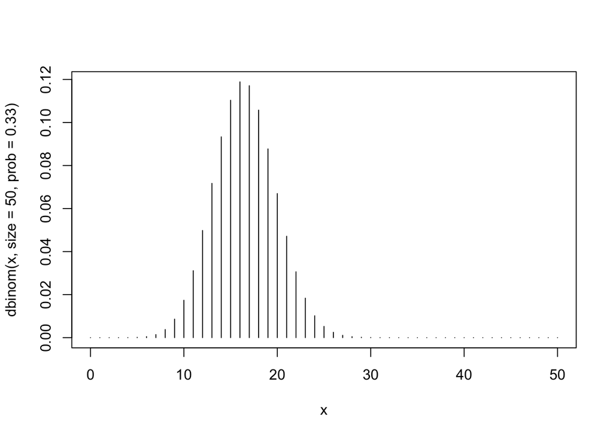

```r
x <- 0:50
plot(x,dbinom(x,size=50,prob=.33),type="h")
```

2. Discrete uniform

```r
library("extraDistr")
```

3. Bernoulli
4. Poisson

```r
size=50
p=.33
lambda=size*p
```

5. Geometric
6. Hyper-geometric
7. Negative binomial

# Problem 2.

Suppose there are fifteen multiple choice questions in `DSAN-5100` midterm test. Each question has four possible answers, and only one of them is correct. Find the probability of having four or less correct answers if a student attempts to answer every question at random.

1. Compute the probability of having exactly 4 correct answers by random attempts using *dbinom()* and *pbinom()*.
2. Find the the probability of having four or less correct answers by random attempts using *dbinom()*.
3. Compute the above probability(part-b) using *pbinom()*.

# Problem 3:

`use r to find the probability`

1. Assume an insurance company receives 3 motor vehicle insurance claims per week. What is the probability that they recieve 11 or fewer claims during a month?

$$P(X\le11)?$$

2. While you are at the Georgetown library terrace, you notice that airplanes fly at an average rate of 1 every 4 hours. What is the probability that you will see at least one plane in the next hour?

# Problem 4:

`Try this example with _..nbinom()_`

(This relates to Problem-1 in Lab-1 Assignment)

Mike had the first three successes in trials 6, 8, and 9. He had six failures until he reached three successes.

Do you think Mike has *success probability p = 0.5 or better?* Can a simulation give an answer?Let’s try.

1. If Mike’s success probability is p = 0.5 What is the probability that he will obtain these 3 successes?.
2. Run many simulations (say 10,000) with this success probability to find the same probability $P(X=6)?$ *Hint: Use rnbinom()*
3. If Mike’s success probability were 0.5 or better, he would not need a lot of attempts. Find the probability that three successes were reached after 9 tosses or later by somebody with success probability 0.5. $P(X\ge6)$
1. Calculate the probabiliy using both *dnbinom()* and *pnbinom()*.
2. Calculate this probability using a Simulation(10,000)
3. Is this probability (part b) the same as you got from “myattempts”: Lab 1 Assignment Problem 1 part 3?